# p8105_hw6_ma4197

Mayuri Albal

2022-12-02

```r
library(tidyverse)
library(modelr)
library(mgcv)
library(rvest)
```

##Problem 1

*Data Loading and Cleaning*

```r
weather_df =
  rnoaa::meteo_pull_monitors(
    c("USW00094728"),
    var = c("PRCP", "TMIN", "TMAX"),
    date_min = "2017-01-01",
    date_max = "2017-12-31") %>%
  mutate(
    name = recode(id, USW00094728 = "CentralPark_NY"),
    tmin = tmin / 10,
    tmax = tmax / 10) %>%
  select(name, id, everything())
```

```
## using cached file: ~/Library/Caches/R/noaa_ghcnd/USW00094728.dly
```

```
## date created (size, mb): 2022-09-08 10:10:02 (8.397)
```

```
## file min/max dates: 1869-01-01 / 2022-09-30
```

*Bootstrap and Plotting Pt 1*

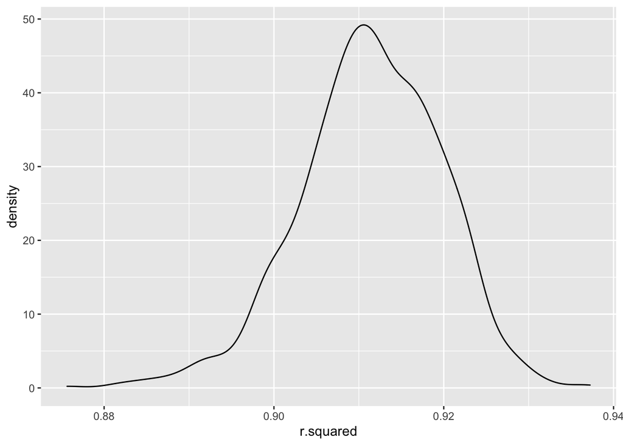

```r
weather_df %>%
  modelr::bootstrap(n = 1000) %>%
  mutate(
    models = map(strap, ~lm(tmax ~ tmin, data = .x) ),
    results = map(models, broom::glance)) %>%
  select(-strap, -models) %>%
  unnest(results) %>%
  ggplot(aes(x = r.squared)) + geom_density()
```

*Plotting Pt 2*

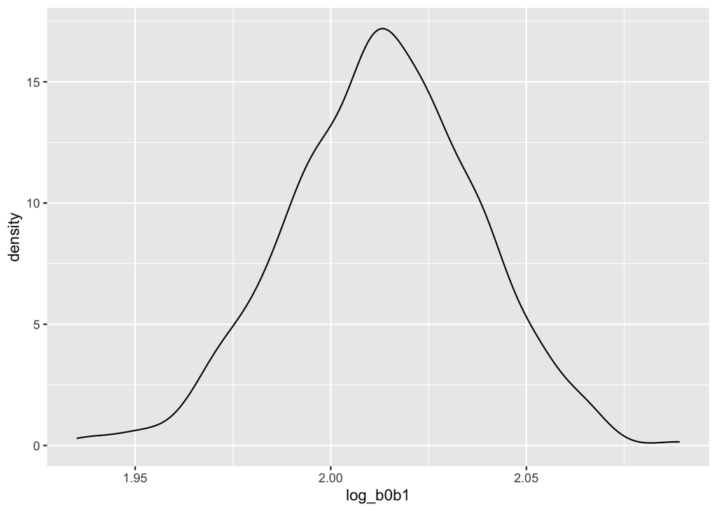

```r
weather_df %>%
  modelr::bootstrap(n = 1000) %>%
  mutate(
    models = map(strap, ~lm(tmax ~ tmin, data = .x) ),
    results = map(models, broom::tidy)) %>%
  select(-strap, -models) %>%
  unnest(results) %>%
  select(id = `.id`, term, estimate) %>%
  pivot_wider(
    names_from = term,
    values_from = estimate) %>%
  rename(beta0 = `(Intercept)`, beta1 = tmin) %>%
  mutate(log_b0b1 = log(beta0 * beta1)) %>%
  ggplot(aes(x = log_b0b1)) + geom_density()
```

##Problem 2

*Data Loading*

```r
twp_data = read_csv(file= "./data/homicide-data.csv") %>%
janitor::clean_names()
```

*Data Cleaning*

```r
murder_df=
twp_data %>%
janitor::clean_names() %>%
mutate(
  state = replace(state, state== "wI", "WI")) %>%
mutate(
  city_state= paste(city, state, sep= ",")) %>%
mutate(
  victim_age = as.numeric(victim_age)) %>%
filter(!city_state %in% c("Dallas,TX","Phoenix,AZ", "Kansas City,MO","Tulsa,AL" )) %>%
filter(victim_race %in% c("White","Black")) %>%
mutate(
    resolved = as.numeric(disposition == "Closed by arrest"))
```

*Description* Within the original data set there are 52,719 observations and 12 variables. The variables names include: ‘uid’, ‘reported_date’, ‘victim_last’, ‘victim_first’, ‘victim_race’, ‘victim_age’, ‘victim_sex’, ‘city’, ‘state’, ‘lat’, ‘lon’, and ‘disposition’. This data was collected across different police department reports from 50 of the largest cities in the United States from the past decade. However, cities ‘Dallas,TX’, “Phoenix,AZ’,”Kansas City,MO’ and ‘Tulsa,AL’ were dropped from the data set due to them not reporting victim race or being a data entry mistake. The variable ‘victim_race’ was filtered to look at only homicides that reported a ‘White’ or ‘Black’ victim. In addition to the homicides classified as ‘Closed by arrest’ were recoded numerically under a new variable ‘resolved’. The final data set was named ‘muder_df’ and had 39,693 observations with 14 variables due to the generation of the ‘city_state’ and ‘resolved’ variables.

*Checks*

```r
murder_df %>%
  group_by(city_state) %>%
  count(city_state)
```

```
## # A tibble: 47 × 2
## # Groups:   city_state [47]
##    city_state         n
##    <chr>          <int>
##  1 Albuquerque,NM   178
##  2 Atlanta,GA       945
##  3 Baltimore,MD    2753
##  4 Baton Rouge,LA   410
##  5 Birmingham,AL    771
##  6 Boston,MA        492
##  7 Buffalo,NY       479
##  8 Charlotte,NC     584
##  9 Chicago,IL      4507
## 10 Cincinnati,OH    679
## # … with 37 more rows
```

```r
murder_df %>%
  summarise(victim_age)
```

```
## # A tibble: 39,693 × 1
##    victim_age
##         <dbl>
##  1         15
##  2         72
##  3         91
##  4         56
##  5         NA
##  6         43
##  7         52
##  8         22
##  9         15
## 10         25
## # … with 39,683 more rows
```

```r
murder_df %>%
  count(victim_race)
```

```
## # A tibble: 2 × 2
##   victim_race     n
##   <chr>       <int>
## 1 Black       33361
## 2 White        6332
```

*Linear Model*

```r
balt_murder_logfit =
  murder_df %>%
  filter(city_state == "Baltimore,MD") %>%
  glm(resolved ~ victim_age + victim_race + victim_sex, data = ., family = binomial())
```

```r
balt_murder_logfit %>%
  broom::tidy() %>%
  mutate(OR = exp(estimate)) %>%
  select(term, log_OR = estimate, OR, p.value) %>%
  knitr::kable(digits = 3)
```

| term | log_OR | OR | p.value |
| --- | --- | --- | --- |
| (Intercept) | 0.310 | 1.363 | 0.070 |
| victim_age | -0.007 | 0.993 | 0.043 |
| victim_raceWhite | 0.842 | 2.320 | 0.000 |
| victim_sexMale | -0.854 | 0.426 | 0.000 |

```r
conf= exp(confint(balt_murder_logfit, level= 0.95))
```

*All City Pipeline*

```r
all_city=
allcity_murder %>%
  filter(term== "victim_sexMale") %>%
  mutate(OR = exp(estimate),
         confh= exp(conf.high),
         confl= exp(conf.low)) %>%
  select(city_state, log_OR = estimate, OR, p.value, confl, confh)
```

```r
all_city=
all_city %>%
mutate(city_state= fct_reorder(city_state, OR))
```

*Plotting*

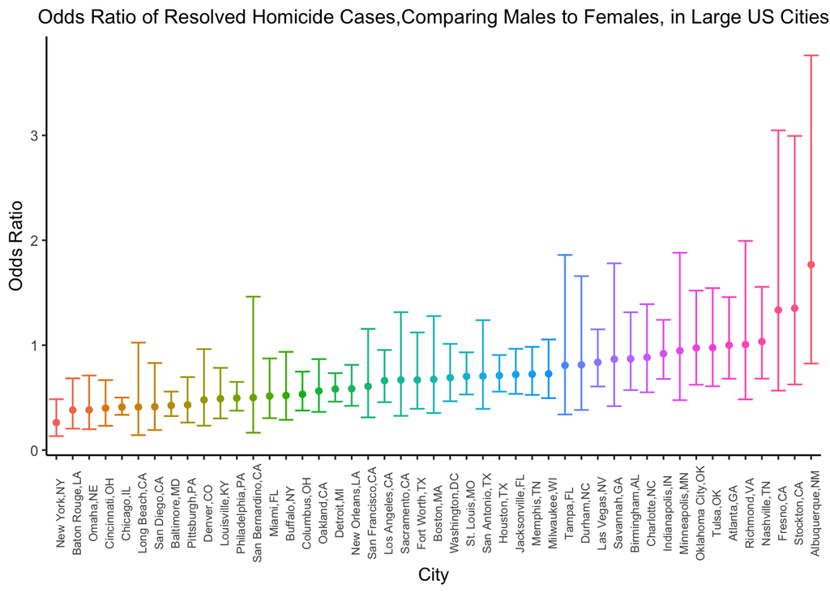

```r
ggplot(all_city, aes(x= city_state, y= OR, color=city_state))+
  geom_point()+
  geom_errorbar(aes(ymin=confl, ymax= confh))+
  theme_classic()+
  theme(legend.position= "none")+
  ggtitle("Odds Ratio of Resolved Homicide Cases,Comparing Males to Females, in Large US Cities")+
  theme(plot.title = element_text(hjust= 0.5, size=12),
        axis.text.x.bottom = element_text(size= 7, angle= 90))+
    labs(x = "City",
        y= "Odds Ratio")
```

##Problem 3

*Load and Clean Data*

```r
bwt_data = read_csv(file= "./data/birthweight.csv") %>%
janitor::clean_names()
bwt_data %>%
tibble
```

```
## # A tibble: 4,342 × 20
##    babysex bhead blength   bwt delwt fincome frace gaweeks malform menarche
##      <dbl> <dbl>   <dbl> <dbl> <dbl>   <dbl> <dbl>   <dbl>   <dbl>    <dbl>
##  1       2    34      51  3629   177      35     1    39.9       0       13
##  2       1    34      48  3062   156      65     2    25.9       0       14
##  3       2    36      50  3345   148      85     1    39.9       0       12
##  4       1    34      52  3062   157      55     1    40         0       14
##  5       2    34      52  3374   156       5     1    41.6       0       13
##  6       1    33      52  3374   129      55     1    40.7       0       12
##  7       2    33      46  2523   126      96     2    40.3       0       14
##  8       2    33      49  2778   140       5     1    37.4       0       12
##  9       1    36      52  3515   146      85     1    40.3       0       11
## 10       1    33      50  3459   169      75     2    40.7       0       12
## # … with 4,332 more rows, and 10 more variables: mheight <dbl>, momage <dbl>,
## #   mrace <dbl>, parity <dbl>, pnumlbw <dbl>, pnumsga <dbl>, ppbmi <dbl>,
## #   ppwt <dbl>, smoken <dbl>, wtgain <dbl>
```

```r
skimr::skim(bwt_data)
```

Data summary

| Name | bwt_data |
| --- | --- |
| Number of rows | 4342 |
| Number of columns | 20 |
| _______________________ |  |
| Column type frequency: |  |
| numeric | 20 |
| ________________________ |  |
| Group variables | None |

**Variable type: numeric**

| skim_variable | n_missing | complete_rate | mean | sd | p0 | p25 | p50 | p75 | p100 | hist |
| --- | --- | --- | --- | --- | --- | --- | --- | --- | --- | --- |
| babysex | 0 | 1 | 1.49 | 0.50 | 1.00 | 1.00 | 1.00 | 2.00 | 2.0 | ▇▁▁▁▇ |
| bhead | 0 | 1 | 33.65 | 1.62 | 21.00 | 33.00 | 34.00 | 35.00 | 41.0 | ▁▁▆▇▁ |
| blength | 0 | 1 | 49.75 | 2.72 | 20.00 | 48.00 | 50.00 | 51.00 | 63.0 | ▁▁▁▇▁ |
| bwt | 0 | 1 | 3114.40 | 512.15 | 595.00 | 2807.00 | 3132.50 | 3459.00 | 4791.0 | ▁▁▇▇▁ |
| delwt | 0 | 1 | 145.57 | 22.21 | 86.00 | 131.00 | 143.00 | 157.00 | 334.0 | ▅▇▁▁▁ |
| fincome | 0 | 1 | 44.11 | 25.98 | 0.00 | 25.00 | 35.00 | 65.00 | 96.0 | ▃▇▅▂▃ |
| frace | 0 | 1 | 1.66 | 0.85 | 1.00 | 1.00 | 2.00 | 2.00 | 8.0 | ▇▁▁▁▁ |
| gaweeks | 0 | 1 | 39.43 | 3.15 | 17.70 | 38.30 | 39.90 | 41.10 | 51.3 | ▁▁▂▇▁ |
| malform | 0 | 1 | 0.00 | 0.06 | 0.00 | 0.00 | 0.00 | 0.00 | 1.0 | ▇▁▁▁▁ |
| menarche | 0 | 1 | 12.51 | 1.48 | 0.00 | 12.00 | 12.00 | 13.00 | 19.0 | ▁▁▂▇▁ |
| mheight | 0 | 1 | 63.49 | 2.66 | 48.00 | 62.00 | 63.00 | 65.00 | 77.0 | ▁▁▇▂▁ |
| momage | 0 | 1 | 20.30 | 3.88 | 12.00 | 18.00 | 20.00 | 22.00 | 44.0 | ▅▇▂▁▁ |
| mrace | 0 | 1 | 1.63 | 0.77 | 1.00 | 1.00 | 2.00 | 2.00 | 4.0 | ▇▇▁▁▁ |
| parity | 0 | 1 | 0.00 | 0.10 | 0.00 | 0.00 | 0.00 | 0.00 | 6.0 | ▇▁▁▁▁ |
| pnumlbw | 0 | 1 | 0.00 | 0.00 | 0.00 | 0.00 | 0.00 | 0.00 | 0.0 | ▁▁▇▁▁ |
| pnumsga | 0 | 1 | 0.00 | 0.00 | 0.00 | 0.00 | 0.00 | 0.00 | 0.0 | ▁▁▇▁▁ |
| ppbmi | 0 | 1 | 21.57 | 3.18 | 13.07 | 19.53 | 21.03 | 22.91 | 46.1 | ▃▇▁▁▁ |
| ppwt | 0 | 1 | 123.49 | 20.16 | 70.00 | 110.00 | 120.00 | 134.00 | 287.0 | ▅▇▁▁▁ |
| smoken | 0 | 1 | 4.15 | 7.41 | 0.00 | 0.00 | 0.00 | 5.00 | 60.0 | ▇▁▁▁▁ |
| wtgain | 0 | 1 | 22.08 | 10.94 | -46.00 | 15.00 | 22.00 | 28.00 | 89.0 | ▁▁▇▁▁ |

```r
bwt_data=
bwt_data %>%
mutate(babysex= recode(babysex,
                 "1"= "Male",
                 "2"= "Female"),
       frace= recode(frace,
                     "1"= "White",
                     "2"= "Black",
                     "3"= "Asian",
                     "4"= "Puerto Rican",
                     "8"= "Other"),
       mrace= recode(mrace,
                     "1"= "White",
                     "2"= "Black",
                     "3"= "Asian",
                     "4"= "Puerto Rican"),
       malform= recode(malform,
                       "0"= "Absent",
                       "1"= "Present"))
skimr::skim(bwt_data)
```

Data summary

| Name | bwt_data |
| --- | --- |
| Number of rows | 4342 |
| Number of columns | 20 |
| _______________________ |  |
| Column type frequency: |  |
| character | 4 |
| numeric | 16 |
| ________________________ |  |
| Group variables | None |

**Variable type: character**

| skim_variable | n_missing | complete_rate | min | max | empty | n_unique | whitespace |
| --- | --- | --- | --- | --- | --- | --- | --- |
| babysex | 0 | 1 | 4 | 6 | 0 | 2 | 0 |
| frace | 0 | 1 | 5 | 12 | 0 | 5 | 0 |
| malform | 0 | 1 | 6 | 7 | 0 | 2 | 0 |
| mrace | 0 | 1 | 5 | 12 | 0 | 4 | 0 |

**Variable type: numeric**

| skim_variable | n_missing | complete_rate | mean | sd | p0 | p25 | p50 | p75 | p100 | hist |
| --- | --- | --- | --- | --- | --- | --- | --- | --- | --- | --- |
| bhead | 0 | 1 | 33.65 | 1.62 | 21.00 | 33.00 | 34.00 | 35.00 | 41.0 | ▁▁▆▇▁ |
| blength | 0 | 1 | 49.75 | 2.72 | 20.00 | 48.00 | 50.00 | 51.00 | 63.0 | ▁▁▁▇▁ |
| bwt | 0 | 1 | 3114.40 | 512.15 | 595.00 | 2807.00 | 3132.50 | 3459.00 | 4791.0 | ▁▁▇▇▁ |
| delwt | 0 | 1 | 145.57 | 22.21 | 86.00 | 131.00 | 143.00 | 157.00 | 334.0 | ▅▇▁▁▁ |
| fincome | 0 | 1 | 44.11 | 25.98 | 0.00 | 25.00 | 35.00 | 65.00 | 96.0 | ▃▇▅▂▃ |
| gaweeks | 0 | 1 | 39.43 | 3.15 | 17.70 | 38.30 | 39.90 | 41.10 | 51.3 | ▁▁▂▇▁ |
| menarche | 0 | 1 | 12.51 | 1.48 | 0.00 | 12.00 | 12.00 | 13.00 | 19.0 | ▁▁▂▇▁ |
| mheight | 0 | 1 | 63.49 | 2.66 | 48.00 | 62.00 | 63.00 | 65.00 | 77.0 | ▁▁▇▂▁ |
| momage | 0 | 1 | 20.30 | 3.88 | 12.00 | 18.00 | 20.00 | 22.00 | 44.0 | ▅▇▂▁▁ |
| parity | 0 | 1 | 0.00 | 0.10 | 0.00 | 0.00 | 0.00 | 0.00 | 6.0 | ▇▁▁▁▁ |
| pnumlbw | 0 | 1 | 0.00 | 0.00 | 0.00 | 0.00 | 0.00 | 0.00 | 0.0 | ▁▁▇▁▁ |
| pnumsga | 0 | 1 | 0.00 | 0.00 | 0.00 | 0.00 | 0.00 | 0.00 | 0.0 | ▁▁▇▁▁ |
| ppbmi | 0 | 1 | 21.57 | 3.18 | 13.07 | 19.53 | 21.03 | 22.91 | 46.1 | ▃▇▁▁▁ |
| ppwt | 0 | 1 | 123.49 | 20.16 | 70.00 | 110.00 | 120.00 | 134.00 | 287.0 | ▅▇▁▁▁ |
| smoken | 0 | 1 | 4.15 | 7.41 | 0.00 | 0.00 | 0.00 | 5.00 | 60.0 | ▇▁▁▁▁ |
| wtgain | 0 | 1 | 22.08 | 10.94 | -46.00 | 15.00 | 22.00 | 28.00 | 89.0 | ▁▁▇▁▁ |

*Description* For the ‘bwt_data’ data set, there are 4342 observations and 20 variables. Within this, the variables ‘babysex’, ‘frace’, ‘mrace’, and ‘malform’ were recoded into their characteristic definitions rather than the numeric values originally assigned. With this, for variable ‘frace’ and ‘mrace’ there were no observations coded as ‘Unknown’, so it was dropped from the data set.

*Linear Modeling*

```r
bwt_model= lm(bwt ~ gaweeks, data=bwt_data)
```

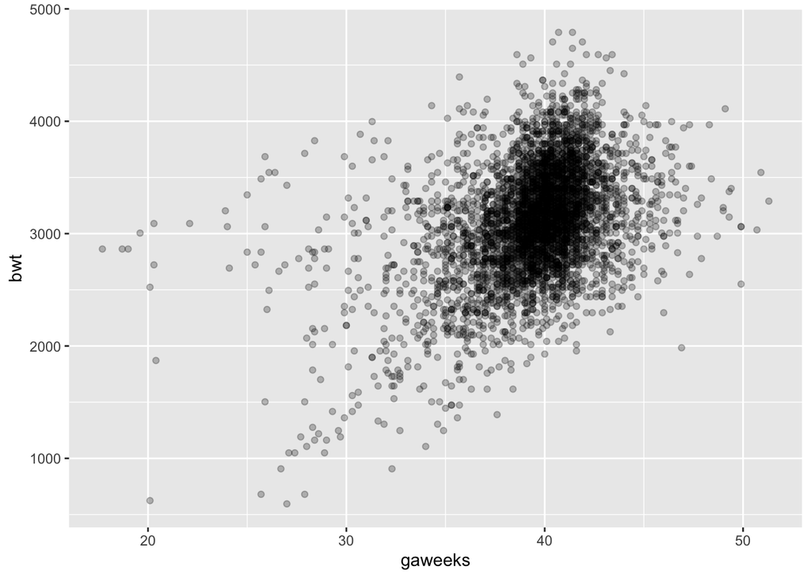

```r
bwt_data %>%
ggplot(aes(x=gaweeks, y=bwt))+
  geom_point(alpha= 0.25)
```

*Description* A typical gestational period is approximately 40 weeks, with any infant born prior to 37 weeks being deemed as a preterm baby. Shorter gestational times are often associated with lower average birth weight of the child, and as a result we will hypothesize that the average birth weight of an infant will be dependent on the gestational period of the pregnancy. This graph above allows us to observe there is a possible positive relationship between the two variables as the shorter the gestational period is, the lower the birth weight is. Additionally, around 40 weeks there are increased observations around the average birth weight range (3000-4000 grams).

*Residual and Prediction Modeling*

```r
modelr::add_residuals(bwt_data, bwt_model)
```

```
## # A tibble: 4,342 × 21
##    babysex bhead blength   bwt delwt fincome frace gaweeks malform menarche
##    <chr>   <dbl>   <dbl> <dbl> <dbl>   <dbl> <chr>   <dbl> <chr>      <dbl>
##  1 Female     34      51  3629   177      35 White    39.9 Absent        13
##  2 Male       34      48  3062   156      65 Black    25.9 Absent        14
##  3 Female     36      50  3345   148      85 White    39.9 Absent        12
##  4 Male       34      52  3062   157      55 White    40   Absent        14
##  5 Female     34      52  3374   156       5 White    41.6 Absent        13
##  6 Male       33      52  3374   129      55 White    40.7 Absent        12
##  7 Female     33      46  2523   126      96 Black    40.3 Absent        14
##  8 Female     33      49  2778   140       5 White    37.4 Absent        12
##  9 Male       36      52  3515   146      85 White    40.3 Absent        11
## 10 Male       33      50  3459   169      75 Black    40.7 Absent        12
## # … with 4,332 more rows, and 11 more variables: mheight <dbl>, momage <dbl>,
## #   mrace <chr>, parity <dbl>, pnumlbw <dbl>, pnumsga <dbl>, ppbmi <dbl>,
## #   ppwt <dbl>, smoken <dbl>, wtgain <dbl>, resid <dbl>
```

```r
modelr::add_predictions(bwt_data, bwt_model)
```

```
## # A tibble: 4,342 × 21
##    babysex bhead blength   bwt delwt fincome frace gaweeks malform menarche
##    <chr>   <dbl>   <dbl> <dbl> <dbl>   <dbl> <chr>   <dbl> <chr>      <dbl>
##  1 Female     34      51  3629   177      35 White    39.9 Absent        13
##  2 Male       34      48  3062   156      65 Black    25.9 Absent        14
##  3 Female     36      50  3345   148      85 White    39.9 Absent        12
##  4 Male       34      52  3062   157      55 White    40   Absent        14
##  5 Female     34      52  3374   156       5 White    41.6 Absent        13
##  6 Male       33      52  3374   129      55 White    40.7 Absent        12
##  7 Female     33      46  2523   126      96 Black    40.3 Absent        14
##  8 Female     33      49  2778   140       5 White    37.4 Absent        12
##  9 Male       36      52  3515   146      85 White    40.3 Absent        11
## 10 Male       33      50  3459   169      75 Black    40.7 Absent        12
## # … with 4,332 more rows, and 11 more variables: mheight <dbl>, momage <dbl>,
## #   mrace <chr>, parity <dbl>, pnumlbw <dbl>, pnumsga <dbl>, ppbmi <dbl>,
## #   ppwt <dbl>, smoken <dbl>, wtgain <dbl>, pred <dbl>
```

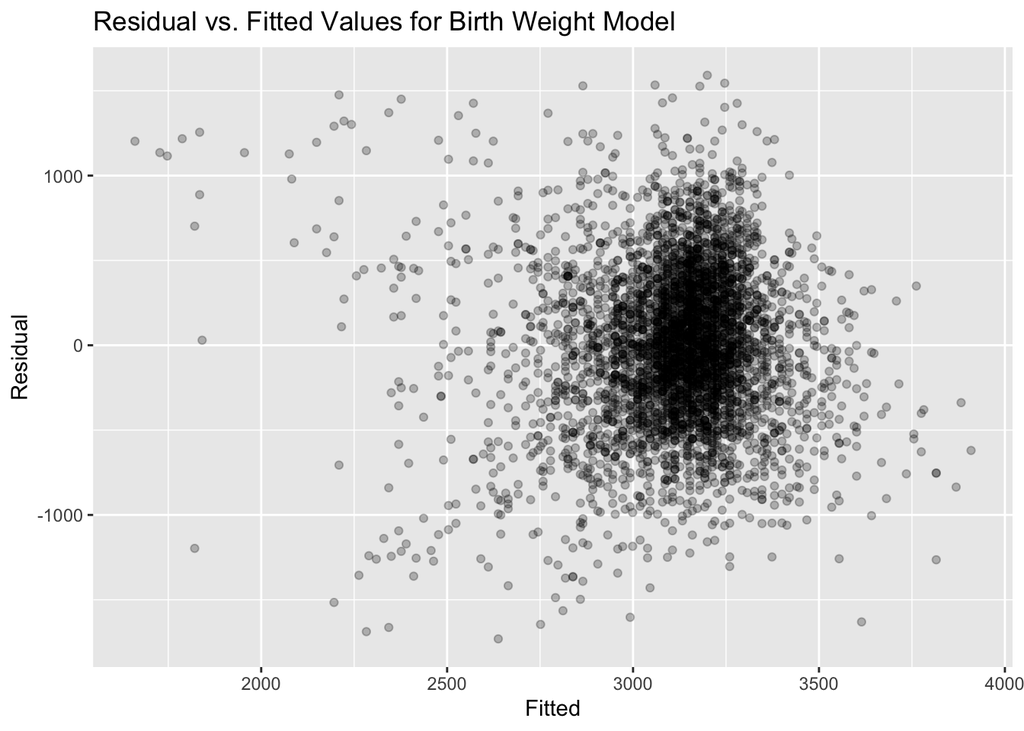

```r
bwt_data %>%
  modelr::add_residuals(bwt_model) %>%
  modelr::add_predictions(bwt_model) %>%
  ggplot(aes(x = pred, y = resid)) + geom_point(alpha=0.25)+
  ggtitle("Residual vs. Fitted Values for Birth Weight Model")+
    labs(x = "Fitted",
        y= "Residual")
```

```r
bwt_model %>%
  broom::tidy() %>%
  knitr::kable()
```

| term | estimate | std.error | statistic | p.value |
| --- | --- | --- | --- | --- |
| (Intercept) | 476.00261 | 88.809089 | 5.359841 | 1e-07 |
| gaweeks | 66.91991 | 2.245363 | 29.803607 | 0e+00 |

*Comparing Models*

```r
bwt_modelme = lm(bwt~ blength + gaweeks, data = bwt_data)
bwt_modeltwi = lm(bwt~ bhead + blength + babysex+ bhead*blength + bhead*babysex + blength*babysex + bhead*blength*babysex, data = bwt_data)
```

*RMSE*

```r
model_df =
  crossv_mc(bwt_data, 100) %>%
  mutate(
    train = map(train, as_tibble),
    test = map(test, as_tibble))

model_df =
  model_df %>%
  mutate(
    bwt_model_n   = map(train, ~lm(bwt ~ gaweeks, data = .x))) %>%
  mutate(
    bwt_modelme_n = map(train, ~lm(bwt ~ blength + gaweeks, data = .x))) %>%
  mutate(
    bwt_modeltwi_n= map(train, ~lm(bwt ~ bhead + blength + babysex+ bhead*blength + bhead*babysex +                          blength*babysex + bhead*blength*babysex, data = .x))) %>%
  mutate(
    rmse_original    = map2_dbl(bwt_model_n, test, ~rmse(model = .x, data = .y)),
    rmse_maineffect  = map2_dbl(bwt_modelme_n, test, ~rmse(model = .x, data = .y)),
    rmse_interaction = map2_dbl(bwt_modeltwi_n, test, ~rmse(model = .x, data = .y)))
```

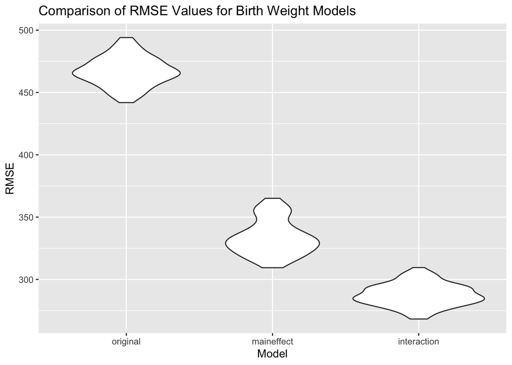

```r
model_df %>%
  select(starts_with("rmse")) %>%
  pivot_longer(
    everything(),
    names_to = "model",
    values_to = "rmse",
    names_prefix = "rmse_") %>%
  mutate(model = fct_inorder(model)) %>%
  ggplot(aes(x = model, y = rmse)) + geom_violin()+
  ggtitle("Comparison of RMSE Values for Birth Weight Models")+
    labs(x = "Model",
        y= "RMSE")
```

*Description* RMSE was utilized to compare each of the three models due to it allowing for us to measure how far predicted values are from the observed values in a regression. With this, the larger the RMSE is, demonstrates a bigger difference between the predicted and observed values. As a result, it determines whether or not the regression is a good fit for the data. By observing violin graphs, it becomes evident that models with lower RSME are a better fit for the data. From this, model 3 (bwt_modeltwi/ Interaction) would be the best fit for this data from the models generated. However, the RMSE for each of the models, including ‘bwt_modeltwi/Interaction’, are quite high showing that there may be a better regression model that fits the data.